# Final Paper

STOR 320/520 Group 10

December 03, 2022

# INTRODUCTION

The National Football League (NFL) in the present day is one of the most popular providers of entertainment in the United States. Thirty-two teams in the league compete against each other in games which regularly top ratings charts, and the finale, the Superbowl, is a de facto holiday. But like many sports, the NFL has a long history which precedes its dominance in American society. Consequently, NFL data presents itself as an excellent source of interesting questions.

For our first question we ask: Can a model predict a team’s home attendance for a season and what predictors are important? For football teams, home attendance is important. After all, they are businesses which wish to make money, and selling tickets is an important contribution to their revenue. Attendance also influences teams’ decisions such as how much security or food is needed and how much a ticket should cost. Thus, having a model capable of predicting home attendance would be helpful in optimizing how a team allocates its resources.

For our second question we ask: What scoring trends have occurred across the NFL’s history? The NFL has a long history, and over this time rules and strategies have changed dramatically. We would like to identify how these changes manifest in our data and create useful graphs for visualizing the changes. Looking back on broad trends of the past will likely not help teams innovate and improve. Nevertheless, scoring trends remain interesting an topic as they recount how the NFL reached where it is today.

# DATA

Our data originated from Tidy Tuesday’s Github which in turn was scraped from the Pro Football Reference website. Tidy Tuesday titled the data ‘NFL Attendance’, but it includes information beyond just attendance. The data covers the seasons from 2000 to 2019 and includes both weekly and season statistics. For our first question we use season statistics because we thought looking at cumulative totals over many games might produce more apparent relationships.

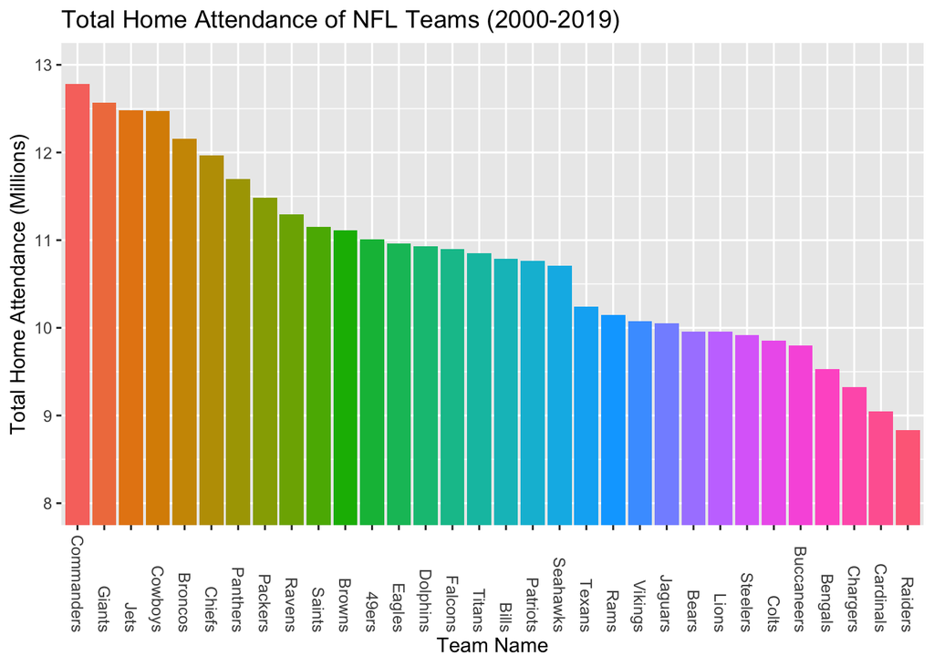

In particular, we use the season home attendance for each team. An NFL team has both home and away games; home games are played at its own stadium and away games at another team’s stadium. In the plot above we show the total home attendance across all seasons in our data. Clearly, some of the 32 teams receive more attendance than others but they all fall between 8 and 13 million in attendance.

| year | team_name | wins | loss | simple_rating |
| --- | --- | --- | --- | --- |
| 2010 | Panthers | 2 | 14 | -13.2 |
| 2011 | Panthers | 6 | 10 | -1.3 |
| 2012 | Panthers | 7 | 9 | 0.8 |
| 2013 | Panthers | 12 | 4 | 9.2 |
| 2014 | Panthers | 7 | 8 | -3.1 |
| 2015 | Panthers | 15 | 1 | 8.1 |
| 2016 | Panthers | 6 | 10 | -1.0 |
| 2017 | Panthers | 11 | 5 | 4.3 |
| 2018 | Panthers | 7 | 9 | 0.9 |
| 2019 | Panthers | 5 | 11 | -7.0 |

In combination with season home attendance, we use teams’ season standings. The table above shows standings of the Carolina Panthers over several seasons. Wins and losses usually sum to 16, the number of games in the regular season. However, the sum is less than 16 if a team happens to tie a game which the Panthers did in 2014. The simple rating is a statistics calculated by Pro Football Reference which takes into account a team’s wins, strength of its opponents, and a its margins of victory. An average team would have simple rating of zero, and above average team would have one greater than 0. The table shows a higher simple rating is correlated with more wins.

| year | week | home_team | away_team | winner | pts_win | pts_loss |
| --- | --- | --- | --- | --- | --- | --- |
| 2019 | 8 | San Francisco 49ers | Carolina Panthers | San Francisco 49ers | 51 | 13 |
| 2019 | 9 | Carolina Panthers | Tennessee Titans | Carolina Panthers | 30 | 20 |
| 2019 | 10 | Green Bay Packers | Carolina Panthers | Green Bay Packers | 24 | 16 |
| 2019 | 11 | Carolina Panthers | Atlanta Falcons | Atlanta Falcons | 29 | 3 |
| 2019 | 12 | New Orleans Saints | Carolina Panthers | New Orleans Saints | 34 | 31 |
| 2019 | 13 | Carolina Panthers | Washington Redskins | Washington Redskins | 29 | 21 |
| 2019 | 14 | Atlanta Falcons | Carolina Panthers | Atlanta Falcons | 40 | 20 |
| 2019 | 15 | Carolina Panthers | Seattle Seahawks | Seattle Seahawks | 30 | 24 |
| 2019 | 16 | Indianapolis Colts | Carolina Panthers | Indianapolis Colts | 38 | 6 |
| 2019 | 17 | Carolina Panthers | New Orleans Saints | New Orleans Saints | 42 | 10 |

For our second question, we use the weekly data. This includes things like the teams playing, yards, and turnovers but the data we use is the season the game occurred and the scores. The table above shows the the scores for a few Carolina Panther games. One problem with applying our data to the second question is that it only spans 20 years. The original source of the data, Pro Football Reference, does have the scores of all NFL games but they are inconveniently spread across multiple web pages. Instead, we used a data set from FiveThirtyEight which contains these scores.

# Question 1

In order to create a model to predict home attendance by multiple continuous predictors and one categorical predictor, first we had to create dummy indicator variables for the categorical variable Team. The variable was split into 32 dummy variables, each representing a team, the last dummy variable, which was for the team “Vikings”, was not included in any models, as it would be calculated in the intercept. Next we looked at a heatmap of the remaining numeric variables correlations as shown here below.

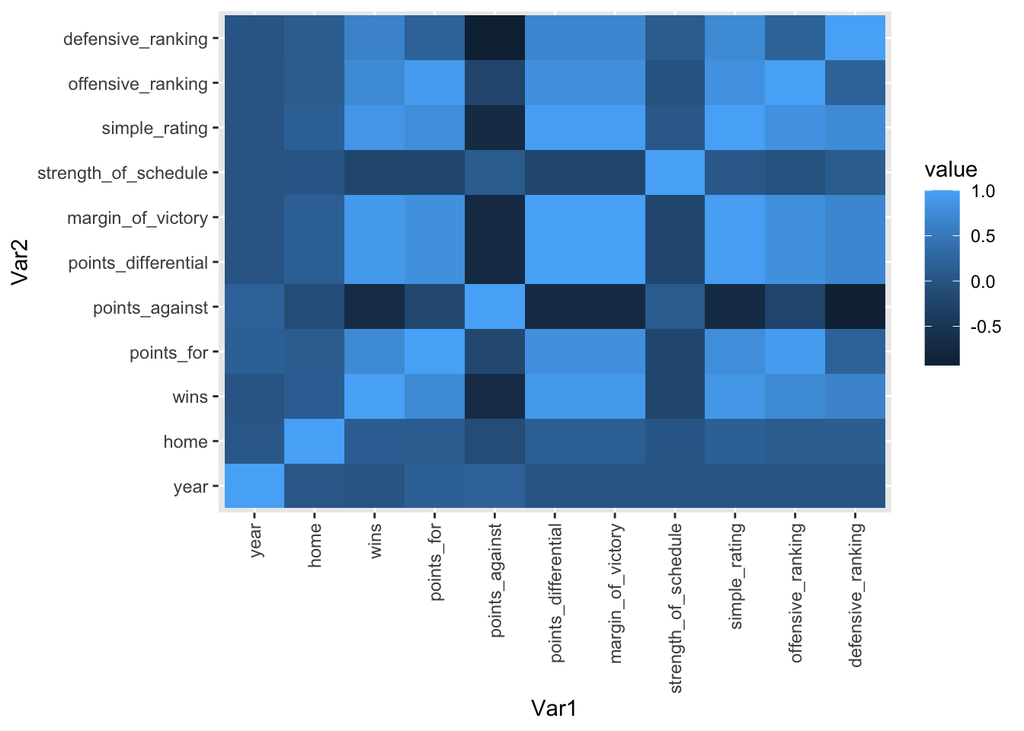

The heatmap shows many numeric variables have very high correlations with each other. These include: offensive_ranking and points_for, simple_rating and wins, simple_rating and offensive ranking, margin_of_victory and wins, margin_of_victory and points_for, margin_of_victory and points_differential, and many others. We decided to remove the variables points_for,points_against,_offensive_ranking, and defensive_ranking to prevent multi-collinearity from clouding our models. After this we split our data into a 70%-30% train-test split and trained and tested each of our models.

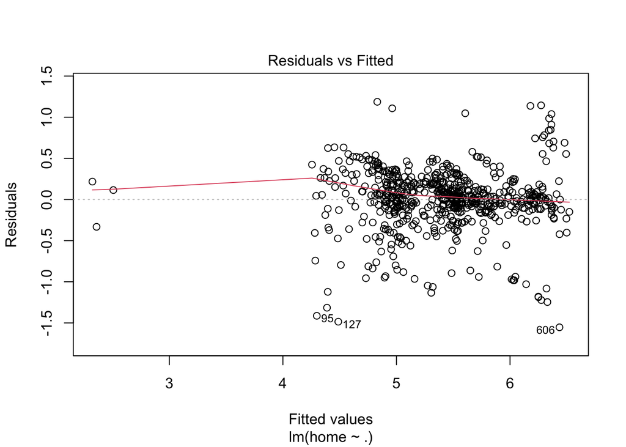

The three methods we decided to use are Ordinary Least Squares (OLS), Ridge Regression, and LASSO Regression. We wanted to start with linear regression due to our response and most of our predictors being numeric. The first model we trained was the OLS model with all predictors. After doing so, we plotted multiple graphs to check that the data indeed fits with a linear model. The residuals plot above shows that a linear model fit fairly well, but there were 3 outliers.

The next model we made was an OLS model that had its predictors chosen by backwards step selection until a model with the lowest AIC was found. This AIC model took out the variables strength_of_schedule, margin_of_victory, points_differential, and wins, leaving the model with the predictors year, simple_rating, and the team dummy variables. After the AIC model we created a ridge regression model that was provided the full model form the first OLS model. Cross Validation was used to try different lambdas to find the most effective model. Lastly for LASSO regression we also implemented Cross Validation to find the most effective lambda parameter and created the best possible model. Below are listed each model type and their respective root mean squared errors when used to predict onto test data.

Models and their RMSEs

| model | rmse |
| --- | --- |
| OLS | 0.4626601 |
| AIC | 0.4590617 |
| Ridge | 0.4626601 |
| LASSO | 0.4986289 |

As seen from the table, the best model for predicting home attendance is the AIC model. When looking at the predictors of this model, we see that only two variables are statistically significant, those being simple_rating and the dummy_variables for each team. Using this new-found knowledge we decided to create another model that pitched home attendance against the interaction between simple_rating and a factored team variable. What we found from this is that three teams had significant interactions with simple_rating, these being the Arizona Cardinals, Dallas Cowboys, and Washington Commanders.

From the results of our AIC model and our interaction model, we find that the home team is the most important variable when it comes to predicting home attendance, which we had been going into this study expecting. We also found that a team’s simple_rating for that season is also significant in accurately predicting home attendance, and that the Cardinals, Cowboys, and Commanders are the most likely to have large fluctuations of attendees based on their performance.

## Question 2

The NFL’s long history and significant shifts in how football is played make analyzing scoring trends an interesting concept. With the plot, we consider how the average points per team has trended over time. We have to factor in the number teams because teams were added to the NFL during the early 2000s. The plot shows that scoring has generally increased over time with a team scoring more than 30 additional points in 2019 than in 2000 on average.

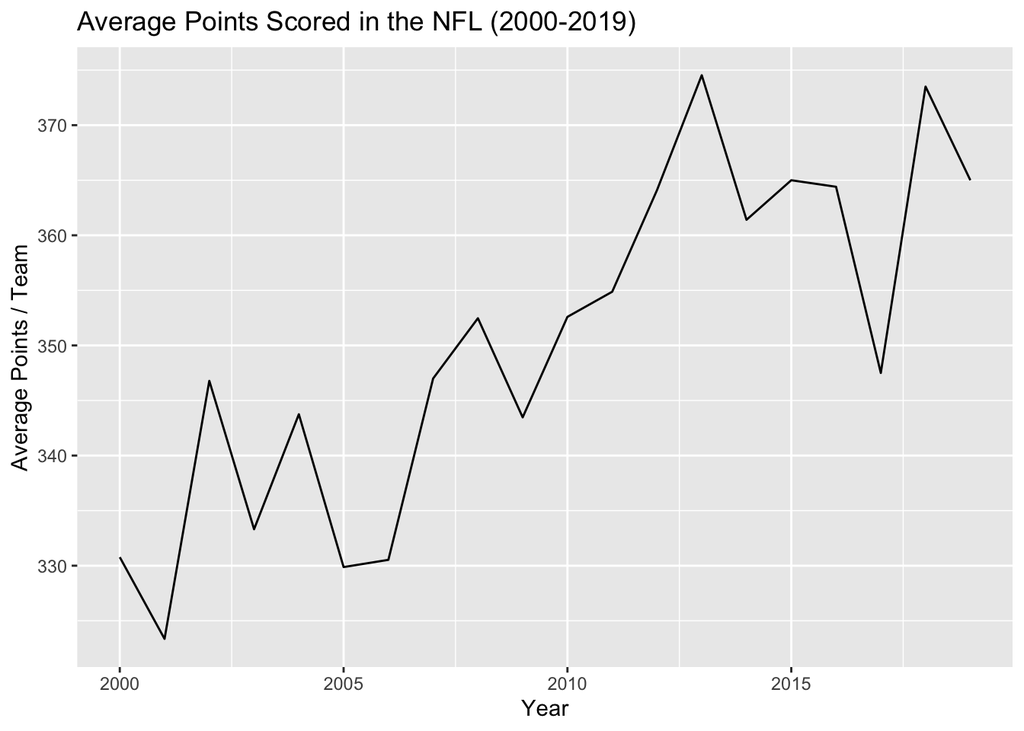

Having observing this trend over 20 years, we wanted to expand the games considered to cover the entire history of the NFL. With the complete scoring history of the NFL, we attempted to create a visual that displayed multiple scoring trends together. What we plotted was a heatmap of different scores. One axis is the winning score and the other the losing score. Since the losing score is less than the winning (or equal to in the case of a tie) half is blank. We accumulated the scores across decades, created a graph for each decade, and switched between them in an animated GIF.

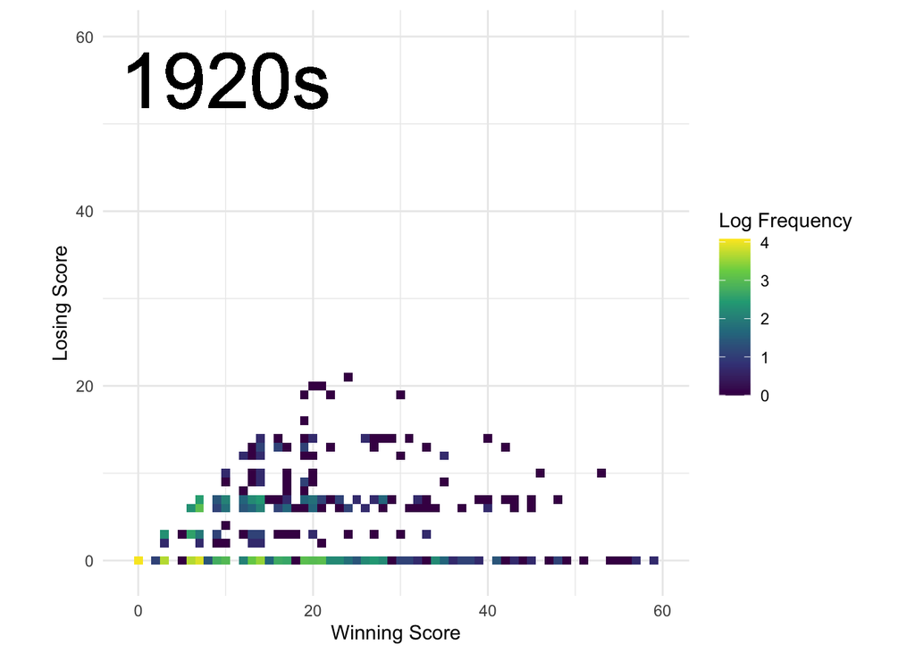

As the decade increases, the frequency of higher scoring games also increases. This is the same trend we saw in the previous plot but on a longer time scale. Even as scores have increased, the most frequent scores have stuck around the plot’s diagonal. This indicates close games where the difference between the winning and losing scores is small continue to occur most often. A notable exception to this is in the early decades of the NFL. At this time, blowout games where the losing team scores zero points were much more frequent than they are in the modern NFL. A final observation from the chart is that the number of unique scores that occur in a decade have increased. The increase in scoring likely contributes to this but a larger influence is the fact that there are more teams and more games in the modern NFL which give more chances for different scores to be achieved.

# CONCLUSION

One question we started with how we might model home attendance. From our analysis, we found that simple rating generally has a positive relationship with home attendance, but it is a weak relationship. The model can be improved by considering the team but this essentially yields 32 separate models. In future analysis, having the maximum stadium capacity for each team and year would useful. This data would allow us to normalize the data across teams. Additionally, more improvements could come in the form of considering new predictors such as weather or a team’s opponents which likely influence attendance.

Our second question asked what scoring trends have occurred during the NFL’s history. The analysis yielded an interesting visual which elucidates several trends in NFL scoring across its history. In general, scoring has increased between the NFL’s founding in 1920 to today. In the future, examining other aspects of the game might show concurrent shifts which underlie the ones we observed.

Overall, we found some interesting trends analyzing attendance and scoring trends. However, there is room for further investigation in both cases to create a more comprehensive analysis and examine finer details. Fortunately, the NFL is not going away soon and will continue to evolve, producing more data and trends to consider.

# DATA

[NFL Attendance](https://github.com/rfordatascience/tidytuesday/blob/master/data/2020/2020-02-04/readme.md)

[FiveThirtyEight’s NFL Data](https://github.com/fivethirtyeight/data/tree/master/nfl-elo)